# DEI Direction-of-Change Study: Technical Appendix

Casey McMahon

2026-05-14

# Overview

This appendix reports analyses for a survey experiment testing how people evaluate organizations that change direction on DEI. Participants read about one organization that either moved from a pro-DEI stance to an anti-DEI stance or from an anti-DEI stance to a pro-DEI stance. The primary outcomes were perceived hypocrisy and genuineness. The study also measured political orientation, DEI support, win-win beliefs about diversity, social dominance orientation, and interest in learning more about the organization.

The public-facing portfolio page uses this study to show that DEI policy changes are interpreted as credibility signals, and that reactions to those changes are shaped by participants’ own political and DEI attitudes.

```r
data <- read_csv("data/dei-direction-change-cleaned.csv")

# Make the contrast direction stable. The anti-DEI -> pro-DEI condition is the reference group.
data <- data %>%
  dplyr::mutate(
    condition_label = factor(
      condition_label,
      levels = c("Anti-DEI to pro-DEI", "Pro-DEI to anti-DEI")
    ),
    over_poli_s = factor(over_poli_s, levels = c("Liberal", "Moderate", "Conservative"))
  )
```

# Sample and data checks

Participants by experimental condition

| Condition | N | Percent |
| --- | --- | --- |
| Anti-DEI to pro-DEI | 179 | 51.4% |
| Pro-DEI to anti-DEI | 169 | 48.6% |

Participant race

| Race | N | Percent |
| --- | --- | --- |
| White | 255 | 73.3% |
| Asian | 24 | 6.9% |
| Black | 26 | 7.5% |
| Hispanic/ Latino/a | 17 | 4.9% |
| Native American | 2 | 0.6% |
| Middle Eastern | 2 | 0.6% |
| Bi/ multiracial | 19 | 5.5% |
| Another race | 3 | 0.9% |

Participants by political orientation group

| Political orientation group | N | Percent |
| --- | --- | --- |
| Liberal | 179 | 51.4% |
| Moderate | 5 | 1.4% |
| Conservative | 164 | 47.1% |

Participant age

| N | M | SD | Min | Max |
| --- | --- | --- | --- | --- |
| 348 | 43.66 | 14.46 | 19.00 | 83.00 |

# Measures and scale reliability

This section summarizes the primary scales used in the study. Higher hypocrisy scores indicate stronger perceptions that the organization acted hypocritically. Higher genuineness scores indicate stronger perceptions that the organization was genuinely committed to its current DEI stance. Higher DEI support, win-win beliefs, and SDO scores indicate stronger endorsement of those constructs.

Scale reliability

| Scale | Cronbach’s alpha |
| --- | --- |
| DEI support | 0.99 |
| Hypocrisy | 0.90 |
| Genuineness | 0.91 |
| Social dominance orientation | 0.92 |
| Win-win beliefs about diversity | 0.99 |

Scale descriptives

| Scale | N | M | SD |
| --- | --- | --- | --- |
| DEI support | 348 | 4.40 | 2.17 |
| Genuineness | 348 | 3.27 | 1.63 |
| Hypocrisy | 348 | 4.86 | 1.48 |
| Political orientation | 348 | 3.84 | 2.21 |
| DEI is good/bad at work | 348 | 0.30 | 0.88 |
| Social dominance orientation | 348 | 2.62 | 1.50 |
| Win-win beliefs | 348 | 4.48 | 1.97 |

Lower-triangle correlations among study variables

| Scale | Hypocrisy | Genuineness | DEI support | DEI is good/bad at work | Social dominance orientation | Win-win beliefs | Political orientation |
| --- | --- | --- | --- | --- | --- | --- | --- |
| Hypocrisy |  |  |  |  |  |  |  |
| Genuineness | -0.73 |  |  |  |  |  |  |
| DEI support | 0.06 | 0.07 |  |  |  |  |  |
| DEI is good/bad at work | 0.03 | 0.08 | 0.88 |  |  |  |  |
| Social dominance orientation | -0.09 | -0.05 | -0.73 | -0.66 |  |  |  |
| Win-win beliefs | 0.05 | 0.05 | 0.85 | 0.81 | -0.74 |  |  |
| Political orientation | -0.09 | -0.01 | -0.74 | -0.69 | 0.64 | -0.74 |  |

# Descriptive differences by direction of change

These descriptive tables show the average outcome ratings in each condition. They provide the simplest version of the study result: whether participants evaluated the pro-DEI to anti-DEI shift differently from the anti-DEI to pro-DEI shift.

Outcome descriptives by condition

| Condition | Outcome | N | M | SD |
| --- | --- | --- | --- | --- |
| Anti-DEI to pro-DEI | Genuineness | 179 | 4.11 | 1.54 |
| Anti-DEI to pro-DEI | Hypocrisy | 179 | 4.46 | 1.40 |
| Anti-DEI to pro-DEI | Interested in learning more | 179 | 0.21 | 0.41 |
| Pro-DEI to anti-DEI | Genuineness | 169 | 2.39 | 1.21 |
| Pro-DEI to anti-DEI | Hypocrisy | 169 | 5.30 | 1.44 |
| Pro-DEI to anti-DEI | Interested in learning more | 169 | 0.18 | 0.38 |

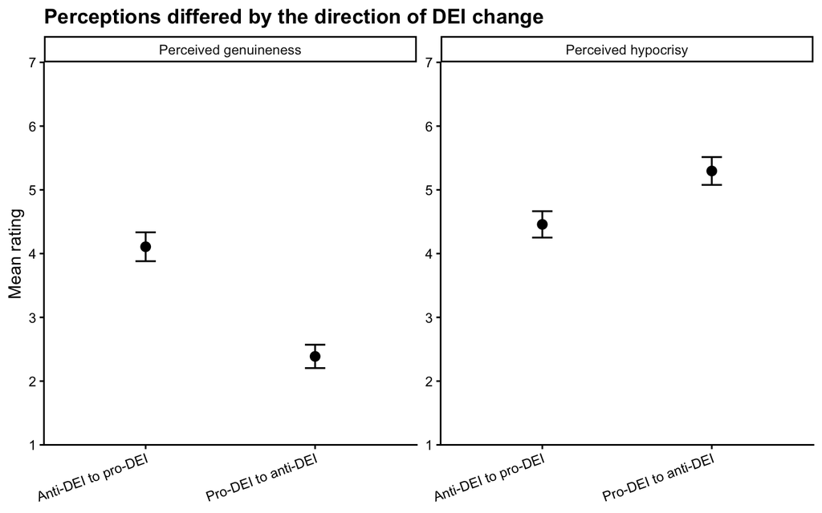

# Main models: hypocrisy

The primary hypothesis for perceived hypocrisy is that people may judge the same act of changing direction differently depending on whether the organization moves away from DEI or toward DEI. These models test whether condition predicts hypocrisy and whether that difference depends on participants’ DEI support or political orientation.

Hypocrisy model with condition only

| Predictor | b | SE | t | p |
| --- | --- | --- | --- | --- |
| Intercept | 4.46 | 0.11 | 42.02 | < .001 |
| condition_labelPro-DEI to anti-DEI | 0.84 | 0.15 | 5.50 | < .001 |

Hypocrisy model with DEI support moderation

| Predictor | b | SE | t | p |
| --- | --- | --- | --- | --- |
| Intercept | 6.23 | 0.38 | 16.37 | < .001 |
| condition_labelPro-DEI to anti-DEI | -1.83 | 0.30 | -6.03 | < .001 |
| DEI support | -0.32 | 0.05 | -5.93 | < .001 |
| Political orientation | -0.10 | 0.05 | -2.12 | 0.034 |
| condition_labelPro-DEI to anti-DEI:div_support | 0.61 | 0.06 | 9.91 | < .001 |

Hypocrisy model with political orientation moderation

| Predictor | b | SE | t | p |
| --- | --- | --- | --- | --- |
| Intercept | 3.98 | 0.39 | 10.24 | < .001 |
| condition_labelPro-DEI to anti-DEI | 2.95 | 0.28 | 10.66 | < .001 |
| Political orientation | 0.17 | 0.06 | 2.95 | 0.003 |
| DEI support | -0.03 | 0.05 | -0.66 | 0.509 |
| condition_labelPro-DEI to anti-DEI:over_poli_r | -0.54 | 0.06 | -8.69 | < .001 |

Association between DEI support and hypocrisy by condition

| condition_label | div_support.trend | SE | df | lower.CL | upper.CL |
| --- | --- | --- | --- | --- | --- |
| Anti-DEI to pro-DEI | -0.32 | 0.05 | 343 | -0.43 | -0.22 |
| Pro-DEI to anti-DEI | 0.29 | 0.06 | 343 | 0.18 | 0.40 |

Association between political orientation and hypocrisy by condition

| condition_label | over_poli_r.trend | SE | df | lower.CL | upper.CL |
| --- | --- | --- | --- | --- | --- |
| Anti-DEI to pro-DEI | 0.17 | 0.06 | 343 | 0.06 | 0.28 |
| Pro-DEI to anti-DEI | -0.38 | 0.06 | 343 | -0.49 | -0.26 |

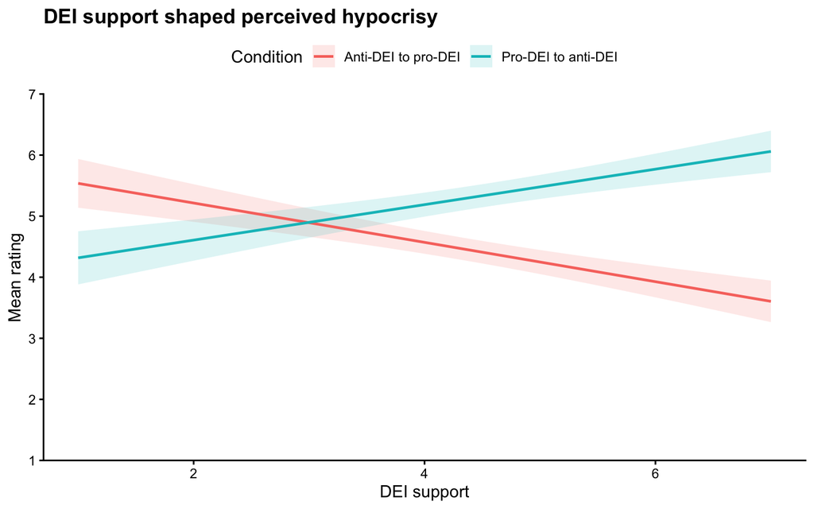

# Main models: genuineness

Genuineness captures whether participants believed the organization was sincerely committed to its current DEI stance. If the pro-DEI to anti-DEI shift is interpreted as more hypocritical, it should also tend to look less genuine.

Genuineness model with condition only

| Predictor | b | SE | t | p |
| --- | --- | --- | --- | --- |
| Intercept | 4.11 | 0.10 | 39.65 | < .001 |
| condition_labelPro-DEI to anti-DEI | -1.72 | 0.15 | -11.57 | < .001 |

Genuineness model with DEI support moderation

| Predictor | b | SE | t | p |
| --- | --- | --- | --- | --- |
| Intercept | 2.12 | 0.39 | 5.40 | < .001 |
| condition_labelPro-DEI to anti-DEI | 0.18 | 0.31 | 0.58 | 0.561 |
| DEI support | 0.35 | 0.06 | 6.25 | < .001 |
| Political orientation | 0.12 | 0.05 | 2.58 | 0.010 |
| condition_labelPro-DEI to anti-DEI:div_support | -0.44 | 0.06 | -6.90 | < .001 |

Genuineness model with political orientation moderation

| Predictor | b | SE | t | p |
| --- | --- | --- | --- | --- |
| Intercept | 3.80 | 0.39 | 9.70 | < .001 |
| condition_labelPro-DEI to anti-DEI | -3.39 | 0.28 | -12.15 | < .001 |
| Political orientation | -0.08 | 0.06 | -1.49 | 0.138 |
| DEI support | 0.14 | 0.05 | 2.93 | 0.004 |
| condition_labelPro-DEI to anti-DEI:over_poli_r | 0.42 | 0.06 | 6.74 | < .001 |

Association between DEI support and genuineness by condition

| condition_label | div_support.trend | SE | df | lower.CL | upper.CL |
| --- | --- | --- | --- | --- | --- |
| Anti-DEI to pro-DEI | 0.35 | 0.06 | 343 | 0.24 | 0.46 |
| Pro-DEI to anti-DEI | -0.09 | 0.06 | 343 | -0.21 | 0.03 |

Association between political orientation and genuineness by condition

| condition_label | over_poli_r.trend | SE | df | lower.CL | upper.CL |
| --- | --- | --- | --- | --- | --- |
| Anti-DEI to pro-DEI | -0.08 | 0.06 | 343 | -0.20 | 0.03 |
| Pro-DEI to anti-DEI | 0.34 | 0.06 | 343 | 0.23 | 0.45 |

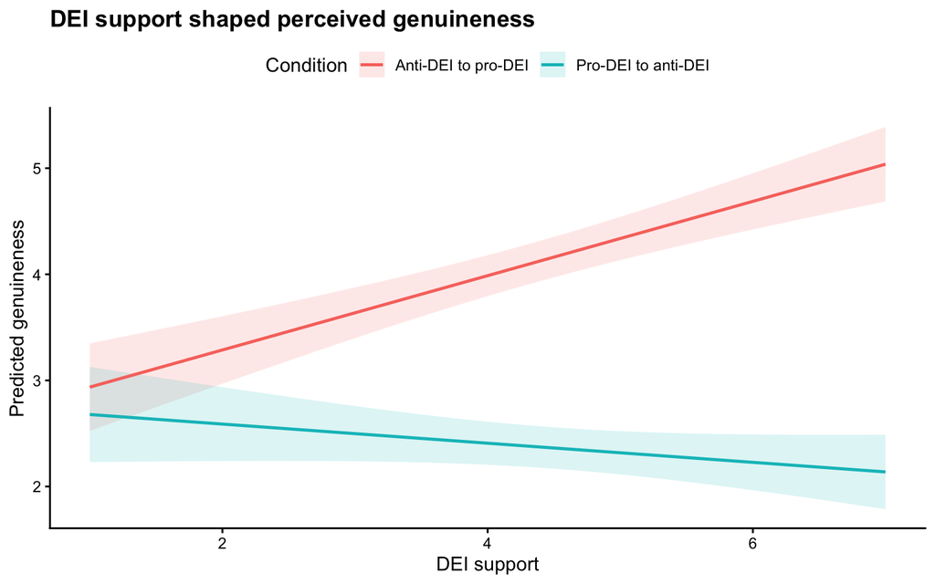

# Interest in learning more

Interest in learning more was exploratory. Because relatively few participants selected yes, these analyses should be interpreted cautiously.

Logistic regression predicting interest in learning more

| Predictor | b | SE | z | p | OR |
| --- | --- | --- | --- | --- | --- |
| Condition: pro-DEI to anti-DEI | 1.10 | 0.70 | 1.56 | 0.118 | 3.00 |
| DEI support | 0.25 | 0.12 | 2.10 | 0.036 | 1.29 |
| Political orientation (higher = more conservative) | -0.02 | 0.09 | -0.22 | 0.823 | 0.98 |
| Pro-DEI to anti-DEI × DEI support | -0.28 | 0.14 | -2.05 | 0.041 | 0.76 |